# [Visão Computacional](https://denmartins.github.io/teaching/2025-visao-computacional)

## Processamento de Imagens Coloridas

### [Prof. Dr. Denis Mayr Lima Martins](https://denmartins.github.io/)

### [Pontifícia Universidade Católica de Campinas](https://www.puc-campinas.edu.br/)

## Objetivos de Aprendizagem

- Compreender os diferentes modelos de cores.
- Explicar como o espaço RGB descreve cada pixel por meio dos componentes R, G e B, incluindo suas limitações em relação à percepção humana.
- Realizar operações lineares e não‑lineares sobre canais/componentes individuais.
- Desenvolver habilidades práticas com ferramentas como OpenCV ou scikit‑image para converter espaços de cor.

## Fundamento de Cores

- **Cor**: percepção visual resultante da interação entre **luz**, **objeto** e **observador**.
- **Modelo físico**: a luz é uma onda eletromagnética.
- **Faixa visível**: 400 nm (violeta) – 700 nm (vermelho).

[figure not shown]

Espectro Eletromagnético. Fonte: [DataHackers.rs](https://www.infoescola.com/fisica/espectro-eletromagnetico/).

## Imagem Colorida

[output not shown]

## Modelos de Cor

- **Espaço Colorido**: Modelo matemático que descreve como combinações de componentes formam todas as cores perceptíveis (ex.: RGB, HSV, CIELAB).
- **RGB (Red, Green, Blue):** aditivo, usado em telas.
- **CMY/CMYK (Cyan, Magenta, Yellow, Black):** subtrativo, usado em impressão.
- **HSI (Hue, Saturation, Intensity):** alinhado à percepção humana.

[figure not shown]

Canais RGB. Fonte: [Color Meanings](https://www.color-meanings.com/cmyk-color-model/).

## Modelos de Cor: RGB

- Cada pixel é descrito por três componentes de intensidade: $R$, $G$ e $B$.
- Os valores são normalmente discretizados em $b_R,b_G,b_B$ bits, resultando num intervalo $[0,2^{b}-1]$.
- **Representação Geométrica**: O conjunto de todas as combinações possíveis forma um *cubo* tridimensional no espaço $(R,G,B)$.

[figure not shown]

Cubo do Modelo RGB. Fonte: [Tudo sobre a cor](https://tudosobreacor.blogspot.com/2011/02/representacao-de-um-cubo-com-as-cores.html).

## Modelos de Cor: RGB (cont.)

Cada vértice do cubo corresponde a uma das oito cores extremas:

- **Linearidade:** Combinações lineares de cores (ex.: mistura de vermelho e verde) são pontos ao longo das arestas.
- **Percepção luminosa:** A distância euclidiana entre dois pontos não reflete necessariamente a diferença perceptual.
- A luminância $L = 0,2126R+0,7152G+0,0722B$ (para sRGB) descreve melhor o brilho percebido.

[figure not shown]

Cubo do Modelo RGB. Fonte: [Wikipedia](https://en.wikipedia.org/wiki/Color_model).

## Modelos de Cor: HSV

- Cada pixel é descrito por três componentes:
  - $H \in [0^\circ,360^\circ)$ (matiz)
  - $S \in [0,1]$ (saturação)
  - $V \in [0,1]$ (valor / luminância)
- **Representação Geométrica**: O conjunto de todas as combinações forma um **cilindro** no espaço tridimensional $(H,S,V)$. A base circular corresponde a $V=1$ (nível máximo de luminância); cada raio da base representa um matiz com saturação máxima; a altura do cilindro é dada por $V$.

[figure not shown]

Cilindro do Modelo HSV. Fonte: [Wikipedia](https://en.wikipedia.org/wiki/Color_model).

## Modelos de Cor: HSV (cont.)

- O modelo é projetado para refletir a percepção humana de cor:
  - *Matiz* determina a cor propriamente dita (vermelho, verde, azul…);
  - *Saturação* indica quão "pura" essa cor está;
  - *Valor* controla o brilho.
- Pontos na borda do cilindro ($S=1$) correspondem a cores "puras" (sem mistura de branco).
- À medida que $V$ diminui, os pontos se movem em direção ao centro do cilindro, representando tons mais escuros ou cinzentos.
- Alterações apenas no componente $H$ giram o ponto ao redor da base circular, mudando a cor sem alterar saturação nem brilho.

[figure not shown]

RGB (esquerda) e HSV (direita). Fonte: [ResearchGate](https://www.researchgate.net/figure/Cube-shaped-RGB-colour-space-left-and-cone-shaped-HSV-colour-space-right_fig14_358828469).

## Usando Scikit-Image

```python
from skimage import data
from skimage.color import rgb2gray,rgb2hsv
```

[figure not shown]

```python
original = data.astronaut()
grayscale = rgb2gray(original)
show_images(original, grayscale)
```

## Observando canais

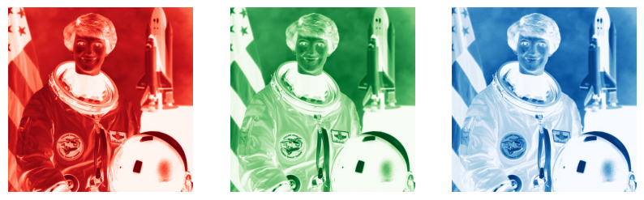

```python
figure, axarr = plt.subplots(1,3, figsize=(10,10))
axarr[0].imshow(original[:,:,0], cmap= 'Reds')
axarr[1].imshow(original[:,:,1], cmap= 'Greens')
axarr[2].imshow(original[:,:,2], cmap= 'Blues')
for ax in axarr.ravel():
        ax.set_axis_off()
plt.show()
```

## Histograma dos Canais RGB

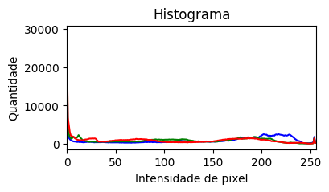

```python
plt.figure(figsize=(4, 2))
color = ('b','g','r')
for i,col in enumerate(color):
    histr = cv2.calcHist([original],[i],None,[256],[0,256])
    plt.plot(histr,color = col)
    plt.xlim([0,256])
plt.title('Histograma')
plt.xlabel('Intensidade de pixel')
plt.ylabel('Quantidade')
plt.show()
```

## Modelo HSV: Aplicação

- Em geral, os objetos presentes em uma cena digital exibem tonalidades (tons) e níveis de luminosidade distintos. No espaço de cores RGB, tanto o tom quanto a luminosidade são obtidos como combinações lineares dos três canais primários R, G e B.
- Ao converter para o modelo HSV (Hue–Saturation–Value), esses atributos se tornam atributos independentes: o canal **H** representa exclusivamente o tom, enquanto o canal **V** encapsula a luminosidade.
- Aplicando um limiar ao canal **H** (ou ao canal **V**, conforme a aplicação), podemos separar uma região de interesse.

```python
# Carrega a imagem de exemplo (café)
rgb_img = data.coffee()
# Converte a representação RGB para HSV.
hsv_img = rgb2hsv(rgb_img)
# Canal de tom (primeiro eixo na matriz HSV)
hue_img = hsv_img[:, :, 0]
# Canal de luminosidade (terceiro eixo)
value_img = hsv_img[:, :, 2]
```

## Modelo HSV: Aplicação (cont.)

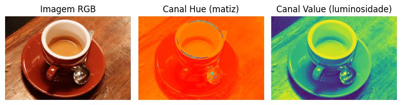

```python
fig, (ax0, ax1, ax2) = plt.subplots(ncols=3, figsize=(8, 3))
ax0.imshow(rgb_img)
ax0.set_title("Imagem RGB")
ax0.axis('off')
# cmap 'hsv' permite observar o ciclo angular das tonalidades
ax1.imshow(hue_img, cmap='hsv')
ax1.set_title("Canal Hue (matiz)")
ax1.axis('off')
# Exibe o canal Value (luminosidade)
ax2.imshow(value_img)
ax2.set_title("Canal Value (luminosidade)")
ax2.axis('off')
plt.tight_layout()
```

## Modelo HSV: Aplicação (cont.)

Separa e visualiza os componentes de cor mais relevantes para tarefas de segmentação baseada em tom ou luminosidade.

```python
# Definição do limiar de tom (hue)
hue_threshold = 0.04
# Criação de uma imagem binária
binary_img = hue_img > hue_threshold
```

## Modelo HSV: Aplicação (cont.)

Separa e visualiza os componentes de cor mais relevantes para tarefas de segmentação baseada em tom ou luminosidade.

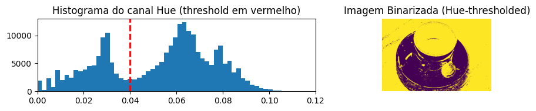

```python
fig, (ax0, ax1) = plt.subplots(ncols=2, figsize=(10, 2))
# `hue_img.ravel()` converte a matriz 2D em um vetor 1D
ax0.hist(hue_img.ravel(), bins=512)
ax0.set_title("Histograma do canal Hue (threshold em vermelho)")
# Linha vermelha pontilhada indica o ponto do limiar
ax0.axvline(x=hue_threshold, color='r', linestyle='dashed', linewidth=2)
# Evita que valores fora de interesse distorçam a escala
ax0.set_xbound(0, 0.12)
ax1.imshow(binary_img)
ax1.set_title("Imagem Binarizada (Hue-thresholded)")
ax1.axis('off')
fig.tight_layout()
```

## Modelo HSV: Removendo parcialmente a sombra

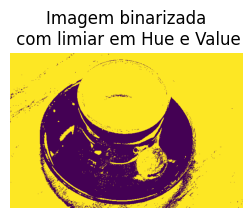

```python
fig, ax0 = plt.subplots(figsize=(3, 3))
value_threshold = 0.10
# Construção da máscara binária que combina duas condições:
# hue_img > hue_threshold: pixels cujo tom excede o limite.
# value_img < value_threshold: pixels com brilho inferior ao limiar.
# Considera cor dominante e contraste de luminosidade
binary_img = (hue_img > hue_threshold) | (value_img < value_threshold)
ax0.imshow(binary_img)
ax0.set_title("Imagem binarizada\n com limiar em Hue e Value")
ax0.axis('off')
plt.show()
```

## Alinhamento de Histogramas (Histogram Matching)

- **Objetivo**: Transformar a distribuição de intensidades (histograma) de uma imagem‑fonte para coincidir com a de uma imagem‑referência.
- Se as imagens possuírem múltiplos canais, o alinhamento é feito independentemente para cada canal, contanto que o número de canais seja igual em ambas.
- **Resultado**: A imagem ajustada mantém a mesma estrutura espacial (textura, bordas) mas com tonalidade e contraste semelhantes ao alvo.

[figure not shown]

Exemplo de Alinhamento de Histograma. Fonte: [OIL MCUT - Digital Image Processing](https://oil-mcut.github.io/img/Chapter4/output_41_1.png).

## Alinhamento de Histogramas: Aplicação

**Procedimento**:

1. Calcula o histograma acumulativo (CDF) da fonte e da referência.
2. Para cada nível de intensidade na fonte, encontra o valor correspondente que possui o mesmo CDF na referência.
3. Substitui os pixels da fonte pelos valores mapeados, preservando a ordem dos intensidades.

```python
from skimage import exposure
from skimage.exposure import match_histograms

reference = data.coffee()
image     = data.chelsea()
# Alinhamento de histogramas: cada canal RGB é tratado separadamente
matched = match_histograms(image, reference, channel_axis=-1)
```

## Alinhamento de Histogramas: Aplicação (cont.)

Pode ser usado como normalização leve em processamento de imagens, especialmente quando as imagens foram capturadas de fontes diferentes ou sob condições distintas (ex.: iluminação).

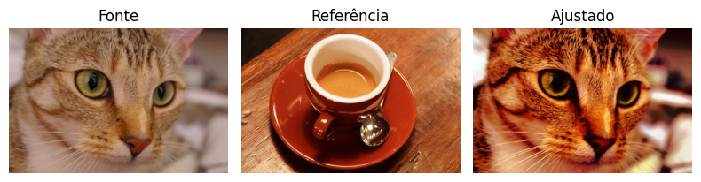

```python
fig, (ax1, ax2, ax3) = plt.subplots(nrows=1, ncols=3, figsize=(8, 3))
for ax in (ax1, ax2, ax3):
    ax.set_axis_off()
ax1.imshow(image)
ax1.set_title('Fonte')
ax2.imshow(reference)
ax2.set_title('Referência')
ax3.imshow(matched)
ax3.set_title('Ajustado')
plt.tight_layout()
```

## Tinting imagens em Grayscale (cont.)

- Já vimos que manipulação de cores pode ser útil em tarefas de realce de regiões de interesse.
- Podemos manipular cores artificialmente uma imagem em grayscale para destacar alguma região. Um processo conhecido como **tinting**.
- A maneira mais simples de obter uma imagem tintada é definir cada canal RGB como a imagem em escala de cinza multiplicada por um fator diferente para cada canal.

```python
from skimage import color
from skimage import img_as_float

# Carrega a imagem de câmera do exemplo (reduzida em 2× para acelerar)
grayscale_image = img_as_float(data.camera()[::2, ::2])
# Converte para RGB (três canais iguais)
image = color.gray2rgb(grayscale_image)
# Fatores de multiplicação para os canais R, G e B
red_multiplier   = [1, 0, 0]   # apenas vermelho
yellow_multiplier = [1, 1, 0]  # vermelho + verde → amarelo
```

## Tinting imagens em Grayscale (cont.)

[figure not shown]

```python
fig, (ax0, ax1, ax2) = plt.subplots(ncols=3, figsize=(8, 4))
ax0.imshow(grayscale_image, cmap="gray")
ax0.set_axis_off()
ax1.imshow(red_multiplier * image)
ax1.set_axis_off()
ax2.imshow(yellow_multiplier * image)
ax2.set_axis_off()
plt.show()
```

## Tinting imagens em Grayscale: Modelo HSV

- Em muitos casos, lidar com valores RGB pode não ser ideal.
- Vamos usar o modelo HSV para tintar a imagem.

```python
def colorize(image, hue, saturation=1):
    """Adiciona a cor da matiz fornecida a uma imagem RGB.

    Por padrão, define a saturação como 1 para que as cores “explodam”.
    """
    hsv = color.rgb2hsv(image) # Converte a imagem RGB para HSV
    hsv[:, :, 1] = saturation # Define a matiz e saturação desejadas
    hsv[:, :, 0] = hue
    return color.hsv2rgb(hsv) # Converte de volta para RGB
```

## Tinting imagens em Grayscale: Modelo HSV (cont.)

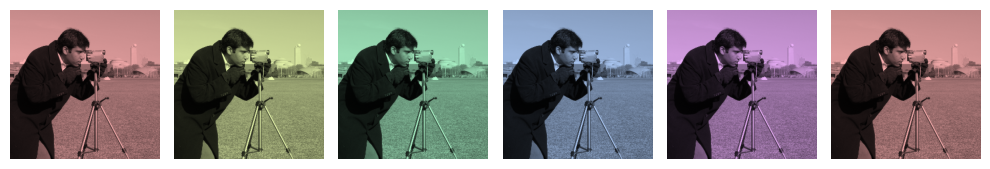

```python
hue_rotations = np.linspace(0, 1, 6)
fig, axes = plt.subplots(nrows=1, ncols=6, figsize=(10, 5))

for ax, hue in zip(axes.flat, hue_rotations):
    # Reduzimos a saturação para dar um visual “vintage”.
    tinted_image = colorize(image, hue, saturation=0.3)
    ax.imshow(tinted_image, vmin=0, vmax=1)
    ax.set_axis_off()
fig.tight_layout()
```

# Convolução de Imagens Coloridas

## Convolução de Imagens Coloridas

- A convolução é aplicada de forma independente em cada canal:
  - $(I * K)_c(x,y) = \sum_{m}\sum_{n} I_c(x-m,\;y-n)\,K(m,n)$, onde $c \in \{R,G,B\}$.

[figure not shown]

Convolução em Imagem RGB. Fonte: [Amaarora](https://amaarora.github.io/fastexplain/2020/07/24/SeNet.html).

- Implementação em Excel por [Thom Lane](https://medium.com/apache-mxnet/multi-channel-convolutions-explained-with-ms-excel-9bbf8eb77108): [link para o Google Sheets](https://docs.google.com/spreadsheets/d/14UTFIgsWlsj3j8TojT7ES18b8oCyN_pSZaMknqLa9kQ/edit?gid=347924595#gid=347924595).

## Convolução de Imagens Coloridas (cont.)

Na terminologia de Visão Computacional, um **feature map** é gerado por canal e, então, somado para formar o resultado final da operação de convolução.

[figure not shown]

Resultado da Convolução em Imagem RGB. Fonte: [Amaarora](https://amaarora.github.io/fastexplain/2020/07/24/SeNet.html).

## Convolução de Imagem Colorida (cont.)

Explore o CNN Explainer: https://poloclub.github.io/cnn-explainer/

[figure not shown]

Convolução em Imagem RGB. Fonte: [DataHackers.rs](https://datahacker.rs/convolution-rgb-image/).

## Convolução de Imagem Colorida (cont.)

[figure not shown]

Convolução em Imagem RGB. Fonte: [DataHackers.rs](https://medium.com/data-science/convolutional-neural-network-ii-a11303f807dc).

## Convolução de Imagem Colorida: Exemplo

[figure not shown]

```python
original = data.astronaut()
kernel = np.ones((5,5), np.float32) / 25 # Filtro de média
media_img = cv2.filter2D(original, -1, kernel) # Convolução
figure, axarr = plt.subplots(1,2, figsize=(6,6))
axarr[0].imshow(original, cmap= 'gray')
axarr[0].set_title("Imagem Original")
axarr[1].imshow(media_img, cmap= 'gray')
axarr[1].set_title("Imagem Suavizada")
for ax in axarr.ravel(): ax.set_axis_off()
plt.show()
```

## Resumo

- **Fundamentos de Cores**: Espaços coloridos, canais, percepções visuais.
- **Representação RGB**: Cada pixel possui três componentes lineares $(R,G,B)$.
- **Convolução**:
  - Operações separadas por canal.
  - O resultado final combina as respostas dos três canais em uma imagem RGB coerente.
  - Base para as [Redes Neurais Convolucionais](https://poloclub.github.io/cnn-explainer/).
- **Leitura adicional**: [CNN Explainer: Learning Convolutional Neural Networks with Interactive Visualization](https://arxiv.org/abs/2004.15004), por Wang, Zijie J., Robert Turko, Omar Shaikh, Haekyu Park, Nilaksh Das, Fred Hohman, Minsuk Kahng, and Duen Horng Chau. *IEEE Transactions on Visualization and Computer Graphics (TVCG), 2020.*

[figure not shown]

**Leitura Recomendada**: Capítulo 6.